# In-Class Session 13: Censored Outcomes, Durations, and Counts

Econometrics I

This notebook reproduces the simulations behind Lectures 13a, 13b, and 13c (the slides use `ldv_sims.R`) and leaves you three problems. Only `fixest` and `survival` are needed; the one model neither package has (zero inflation) is written out as a likelihood.

# Part 1: Censoring and Tobit

## Reproduce: spending with many zeros

Latent spending $y^* = -0.5 + 1.5x + \varepsilon$, $\varepsilon \sim N(0, 2^2)$; observed $y = \max(0, y^*)$.

```r
sim_tobit <- function(N = 2000, b0 = -0.5, b1 = 1.5, sig = 2, hetero = 0) {
  x <- rnorm(N)
  e <- rnorm(N, 0, sig * exp(hetero * x))      # hetero > 0: variance rises with x
  ystar <- b0 + b1 * x + e
  data.frame(x, ystar, y = pmax(0, ystar))
}
d <- sim_tobit()
mean(d$y == 0)
```

```
## [1] 0.578
```

OLS on everyone, OLS on the buyers, and the Tobit (a left-censored normal regression):

```r
ols_all <- lm(y ~ x, d)
ols_pos <- lm(y ~ x, d, subset = y > 0)
tob     <- survreg(Surv(y, y > 0, type = "left") ~ x, d, dist = "gaussian")
rbind(ols_all = coef(ols_all), ols_pos = coef(ols_pos), tobit = coef(tob))
```

```
##         (Intercept)         x
## ols_all   0.7434541 0.5912825
## ols_pos   1.4716741 0.5250614
## tobit    -0.4546727 1.3855933
```

```r
tob$scale                                       # sigma (truth 2)
```

```
## [1] 1.937589
```

The probit check: a probit on $1\{y > 0\}$ should give about $\beta/\sigma = 0.75$.

```r
pro <- feglm(I(y > 0) ~ x, d, family = binomial("probit"))
c(probit_slope = unname(coef(pro)[2]), tobit_ratio = unname(coef(tob)[2] / tob$scale))
```

```
## probit_slope  tobit_ratio
##    0.7462045    0.7151122
```

Marginal effect on observed spending, averaged over the sample:

```r
coef(tob)[2] * mean(pnorm(predict(tob, type = "lp") / tob$scale))
```

```
##         x
## 0.5859074
```

# In-class problem 1: when Tobit breaks

Re-simulate with `hetero = 0.4`, so the error variance grows with income. Tobit assumes homoskedastic normal errors.

**(a)** Re-estimate the Tobit and the probit. Does the probit check still agree with $\hat\beta/\hat\sigma$? Which is further from the truth, the OLS slope or the Tobit slope? **(b)** One sentence: why does heteroskedasticity break Tobit’s *consistency* when it only breaks OLS’s standard errors?

```r
# your code here
```

# Part 2: Duration models

## Reproduce: subscription churn

Weibull hazard with proportional effects: $h(t \mid x) = p\,t^{p-1}\exp(0.5\,\text{price} - 0.4\,\text{usage})$, $p = 0.7$. Observation stops at 24 months; some subscribers drop out of the panel early for unrelated reasons.

```r
sim_churn <- function(N = 3000, p = 0.7, b_price = 0.5, b_usage = -0.4, scale = 17) {
  price <- rbinom(N, 1, 0.5); usage <- rnorm(N)
  T_true <- (-log(runif(N)) / exp(b_price * price + b_usage * usage))^(1 / p) * scale
  C <- pmin(24, ifelse(runif(N) < 0.15, runif(N, 1, 24), 24))
  data.frame(time = pmin(T_true, C), event = as.integer(T_true <= C), price, usage)
}
dd <- sim_churn()
mean(dd$event == 0)                             # share censored
```

```
## [1] 0.2396667
```

Kaplan-Meier by group, then Cox and Weibull. `survreg` reports the accelerated-failure-time form; divide by minus the scale to get proportional-hazards coefficients.

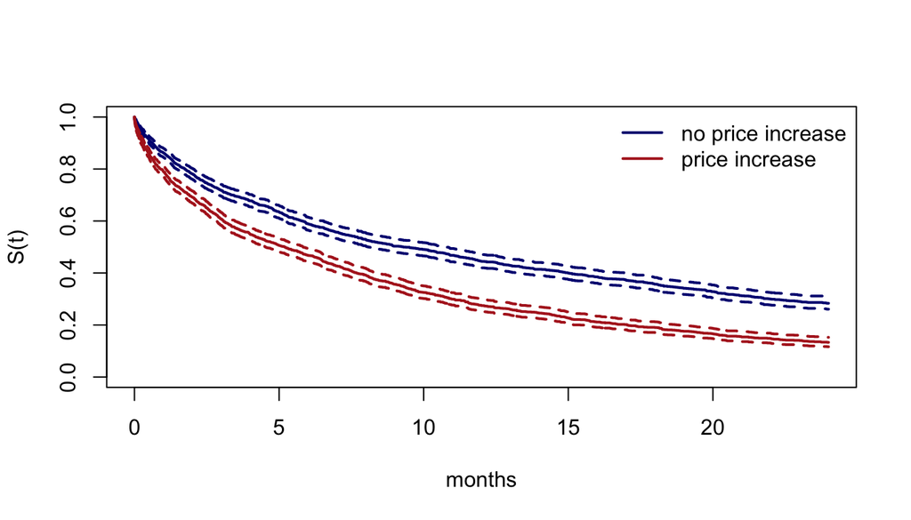

```r
km <- survfit(Surv(time, event) ~ price, dd)
plot(km, col = c("navy", "firebrick"), lwd = 2, conf.int = TRUE, xlab = "months", ylab = "S(t)")
legend("topright", bty = "n", legend = c("no price increase", "price increase"), col = c("navy", "firebrick"), lwd = 2)
```

```r
cox <- coxph(Surv(time, event) ~ price + usage, dd)
wei <- survreg(Surv(time, event) ~ price + usage, dd, dist = "weibull")
rbind(cox = coef(cox), weibull_PH = -coef(wei)[-1] / wei$scale)
```

```
##                price      usage
## cox        0.5041440 -0.3821573
## weibull_PH 0.5010375 -0.3797361
```

```r
1 / wei$scale                                   # Weibull shape p (truth 0.7)
```

```
## [1] 0.6955901
```

```r
exp(coef(cox))                                  # hazard ratios
```

```
##     price     usage
## 1.6555677 0.6823877
```

## Reproduce: the same model as a person-month logit, with fixest only

Expand each spell into one row per month at risk, with an exit indicator in the last month of completed spells. A complementary log-log link with month fixed effects is the discrete-time version of proportional hazards.

```r
pm <- do.call(rbind, lapply(seq_len(nrow(dd)), function(i) {
  m <- seq_len(ceiling(dd$time[i]))
  data.frame(id = i, month = m, price = dd$price[i], usage = dd$usage[i],
             exit = as.integer(m == max(m) & dd$event[i] == 1))
}))
nrow(pm)
```

```
## [1] 29872
```

```r
disc <- feglm(exit ~ price + usage | month, pm, family = binomial("cloglog"), vcov = ~id)
rbind(cox = coef(cox), discrete_cloglog = coef(disc))
```

```
##                      price      usage
## cox              0.5041440 -0.3821573
## discrete_cloglog 0.5029893 -0.3841588
```

# In-class problem 2: heterogeneity that looks like duration dependence

Simulate 3,000 subscribers of two types with *constant* hazards: half have monthly hazard 0.04, half 0.30 (draw `T = rexp(n, rate)`). Censor at 24 months.

**(a)** Fit a Weibull with no covariates and report the shape $p$. Is it below one? **(b)** Now add the type indicator as a covariate. What happens to $p$? **(c)** One sentence: in the churn data you will actually see, what would you need in order to tell falling individual hazards apart from sorting?

```r
# your code here
```

# Part 3: Count data

## Reproduce: purchases per customer-quarter

Rate $\lambda_i = E_i \exp(-0.5 + 0.6\,\text{promo} + 0.2\,\text{tenure})\,\nu_i$ with gamma heterogeneity $\nu_i$ (variance 0.8), exposure $E_i \in \{1,2,3\}$ months, and 25% never-buyers.

```r
sim_counts <- function(N = 4000, alpha = 0.8, pi0 = 0.25) {
  promo <- rbinom(N, 1, 0.5); tenure <- rnorm(N); months <- sample(1:3, N, replace = TRUE)
  nu <- rgamma(N, shape = 1 / alpha, rate = 1 / alpha)
  lam <- months * exp(-0.5 + 0.6 * promo + 0.2 * tenure) * nu
  y <- ifelse(rbinom(N, 1, pi0) == 1, 0L, rpois(N, lam))
  data.frame(y, promo, tenure, months)
}
dc <- sim_counts()
c(mean = mean(dc$y), var = var(dc$y), zeros = mean(dc$y == 0))
```

```
##     mean      var    zeros
## 1.355250 5.242358 0.527750
```

Poisson (with and without robust standard errors) and negative binomial, all `fixest`, with the exposure as an offset:

```r
pois     <- fepois(y ~ promo + tenure, dc, offset = ~log(months), vcov = "iid")
pois_rob <- fepois(y ~ promo + tenure, dc, offset = ~log(months), vcov = "hetero")
nb       <- fenegbin(y ~ promo + tenure, dc, offset = ~log(months))
etable(pois, pois_rob, nb, headers = c("Poisson", "Poisson robust", "NB"))
```

```
##                                pois            pois_rob                  nb
##                             Poisson      Poisson robust                  NB
## Dependent Var.:                   y                   y                   y
##
## Constant        -0.7804*** (0.0231) -0.7804*** (0.0375) -0.7907*** (0.0372)
## promo            0.6433*** (0.0284)  0.6433*** (0.0501)  0.6559*** (0.0501)
## tenure           0.2139*** (0.0137)  0.2139*** (0.0239)  0.2219*** (0.0250)
## _______________ ___________________ ___________________ ___________________
## Family                      Poisson             Poisson           Neg. Bin.
## S.E. type                       IID Heteroskedast.-rob.                 IID
## Observations                  4,000               4,000               4,000
## Squared Cor.                0.11671             0.11671             0.11649
## Pseudo R2                   0.10593             0.10593             0.04165
## BIC                        14,865.3            14,865.3            12,012.4
## Over-dispersion                  --                  --             0.63920
## ---
## Signif. codes: 0 '***' 0.001 '**' 0.01 '*' 0.05 '.' 0.1 ' ' 1
```

```r
1 / nb$theta                                    # overdispersion alpha (NB alone over-attributes)
```

```
##   .theta
## 1.564445
```

The zero-inflated negative binomial, as a likelihood handed to `optim`:

```r
X <- cbind(1, dc$promo, dc$tenure); off <- log(dc$months); y <- dc$y
zinb_nll <- function(th) {
  la <- exp(X %*% th[1:3] + off); a <- exp(th[4]); pi <- plogis(th[5])
  f <- dnbinom(y, size = 1 / a, mu = la)
  -sum(ifelse(y == 0, log(pi + (1 - pi) * f), log(1 - pi) + log(f)))
}
zinb <- optim(c(coef(nb)[1:3], log(1 / nb$theta), 0), zinb_nll, method = "BFGS", hessian = TRUE)
setNames(c(zinb$par[1:3], exp(zinb$par[4]), plogis(zinb$par[5])), c("const", "promo", "tenure", "alpha", "pi"))
```

```
##      const      promo     tenure      alpha         pi
## -0.5179519  0.6620408  0.2131215  0.7868717  0.2396675
```

Model comparison: AIC, BIC, and the Vuong test of ZINB against NB.

```r
ll <- c(pois = as.numeric(logLik(pois)), nb = as.numeric(logLik(nb)), zinb = -zinb$value)
k <- c(3, 4, 5)
rbind(AIC = -2 * ll + 2 * k, BIC = -2 * ll + log(nrow(dc)) * k)
```

```
##         pois       nb     zinb
## AIC 14846.41 11995.53 11963.05
## BIC 14865.30 12020.71 11994.52
```

```r
la_z <- exp(X %*% zinb$par[1:3] + off); a_z <- exp(zinb$par[4]); pi_z <- plogis(zinb$par[5])
f_z  <- ifelse(y == 0, pi_z + (1 - pi_z) * dnbinom(0, size = 1 / a_z, mu = la_z), (1 - pi_z) * dnbinom(y, size = 1 / a_z, mu = la_z))
f_nb <- dnbinom(y, size = nb$theta, mu = fitted(nb))
m <- log(f_z) - log(f_nb)
c(vuong_z = sqrt(length(m)) * mean(m) / sd(m))   # positive favors ZINB
```

```
##  vuong_z
## 2.946821
```

## Reproduce: counts in a panel, Poisson FE versus log(1+y)

Heavy buyers are targeted with more promotions, so promo is correlated with the customer effect.

```r
sim_panel <- function(N = 1500, T = 8, targeting = 0.8) {
  pd <- expand.grid(id = 1:N, q = 1:T)
  pd$eta <- rnorm(N, 0, 0.8)[pd$id]
  pd$promo <- rbinom(nrow(pd), 1, plogis(-0.5 + targeting * pd$eta))
  pd$y <- rpois(nrow(pd), exp(-0.8 + 0.6 * pd$promo + pd$eta))
  pd
}
pd <- sim_panel()
etable(fepois(y ~ promo, pd, vcov = ~id),
       fepois(y ~ promo | id, pd, vcov = ~id),
       feols(log1p(y) ~ promo | id, pd, vcov = ~id),
       headers = c("Poisson", "Poisson + FE", "log(1+y) + FE"))
```

```
##                 fepois(y ~ promo,.. fepois(y ~ promo.. feols(log1p(y) ~..
##                             Poisson       Poisson + FE      log(1+y) + FE
## Dependent Var.:                   y                  y           log1p(y)
##
## Constant        -0.7191*** (0.0261)
## promo             1.071*** (0.0347) 0.5832*** (0.0234) 0.2217*** (0.0097)
## Fixed-Effects:  ------------------- ------------------ ------------------
## id                               No                Yes                Yes
## _______________ ___________________ __________________ __________________
## Family                      Poisson            Poisson                OLS
## S.E.: Clustered              by: id             by: id             by: id
## Observations                 12,000             11,232             12,000
## Squared Cor.                0.11515            0.57426            0.48899
## Pseudo R2                   0.08471            0.28207            0.41472
## BIC                        30,704.2           36,200.3           25,468.3
## ---
## Signif. codes: 0 '***' 0.001 '**' 0.01 '*' 0.05 '.' 0.1 ' ' 1
```

# In-class problem 3: which columns move?

Re-simulate the panel with `targeting = 0` (promotions assigned at random) and re-run the three regressions.

**(a)** Which columns change and which do not? Explain each in one line. **(b)** The $\log(1+y)$ coefficient is still far from 0.6 even with random assignment. What is it estimating? (Hint: Week 2, the transformations deck.) **(c)** Rerun with `T = 2` and then `T = 30`. Does the Poisson fixed-effects estimate change with $T$? Compare to what you know about the logit with fixed effects.

```r
# your code here
```